# Data 621 Final Project

```r
  #theme_bw()
```

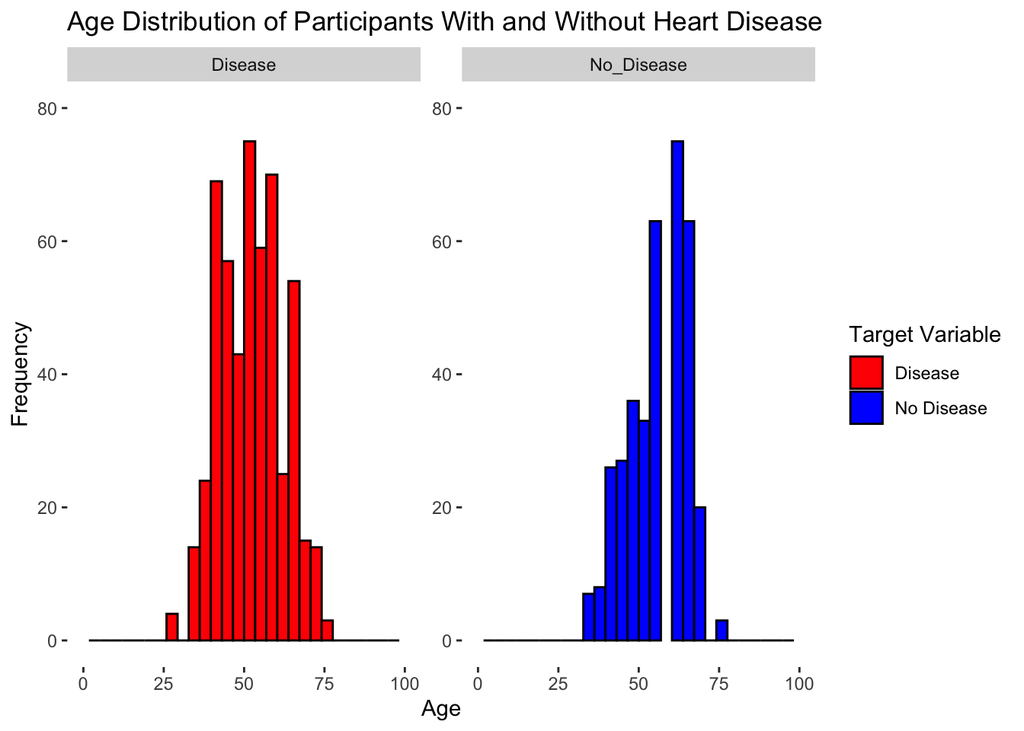

```r
ggplot(mydata.clean, aes(x=age, fill=factor(target))) +
geom_histogram(bindwith = 4, position = "dodge", color = "black")+
  xlim(0,100)+
  ylim(0,80)+
labs(title="Age Distribution of Participants With and Without Heart Disease", x="Age", y="Frequency", fill="Target Variable") +
scale_fill_manual(values =c("No_Disease" = "blue", "Disease" = "red"), labels= c("Disease", "No Disease"))+
facet_wrap(~target, scales = "free_y", labeller = labeller(target =
    c("No Disease" = "No Disease",
      "Disease" = "Disease")))+
  theme(panel.background = element_blank())
```

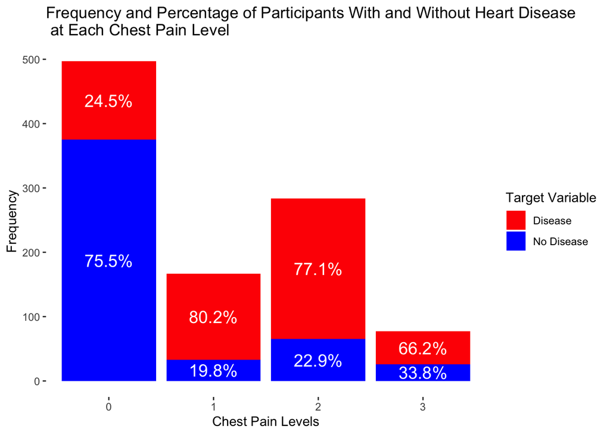

```r
mydata.clean %>%

  group_by(chest_pain, target) %>%

  summarise(count = n()) %>%

  group_by(chest_pain) %>%

  mutate(percentage = (count / sum(count)) * 100) %>%

ggplot(aes(x=chest_pain, y=count, fill= factor(target))) +
  geom_bar(stat = "identity")+
  geom_text(aes(label = paste0(round(percentage, 1), "%")),
            position = position_stack(vjust = 0.5), size = 5, color = "white") +
  labs(title="Frequency and Percentage of Participants With and Without Heart Disease \n at Each Chest Pain Level", x="Chest Pain Levels", y="Frequency", fill="Target Variable")+
  scale_fill_manual(values= c("No_Disease" = "blue", "Disease"= "red"), labels= c("Disease", "No Disease"))+
  # facet_wrap(~target, scales = "free_y", labeller = labeller(target =
  #   c("0" = "No Disease",
  #     "1" = "Disease")))+
  theme(panel.background = element_blank())
```

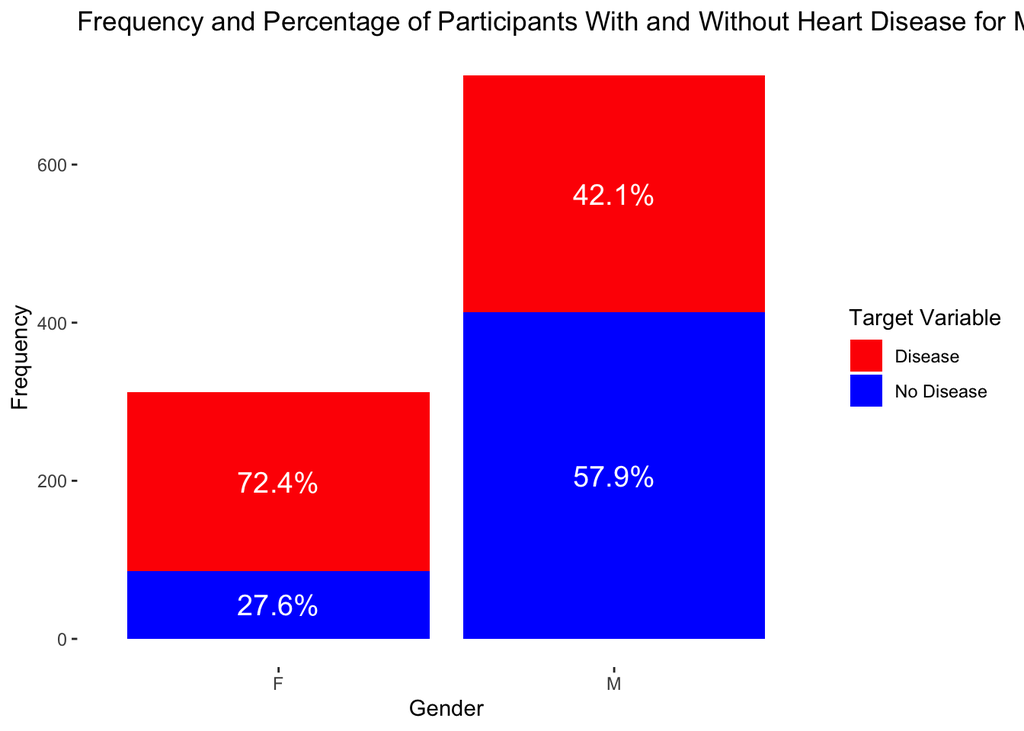

```r
mydata.clean %>%

  group_by(sex, target) %>%

  summarise(count = n()) %>%

  group_by(sex) %>%

  mutate(percentage = (count / sum(count)) * 100) %>%

ggplot(aes(x=sex, y=count, fill= factor(target))) +
  geom_bar(stat = "identity")+
  geom_text(aes(label = paste0(round(percentage, 1), "%")),
            position = position_stack(vjust = 0.5), size = 5, color = "white") +
  labs(title="Frequency and Percentage of Participants With and Without Heart Disease for Males and Females", x="Gender", y="Frequency", fill="Target Variable")+
  scale_fill_manual(values= c("No_Disease" = "blue", "Disease"= "red"), labels= c("Disease", "No Disease"))+
  theme(panel.background = element_blank())
```

```r
# mydata.clean %>%

  # group_by(sex, target) %>%
  #
  # summarise(count = n())
```

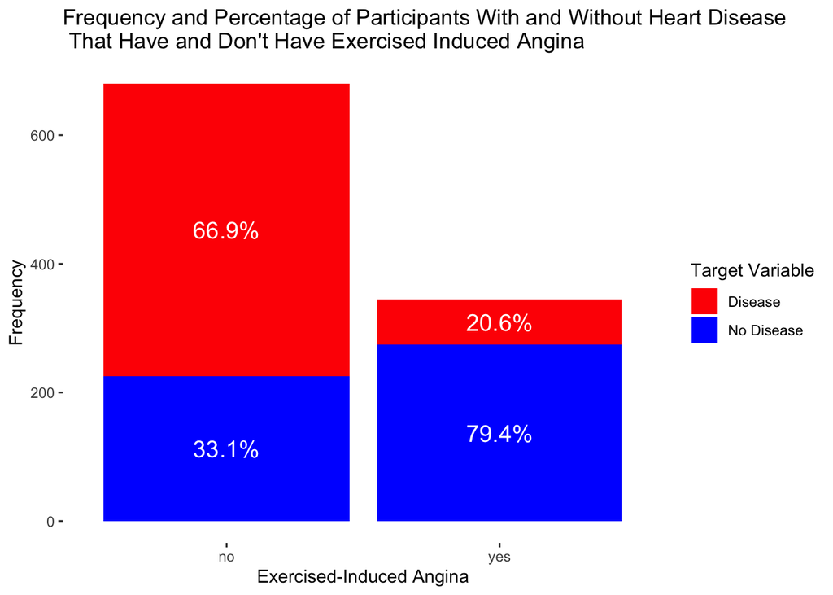

```r
mydata.clean %>%

  group_by(exercise_induced_angina, target) %>%

  summarise(count = n()) %>%

  group_by(exercise_induced_angina) %>%

  mutate(percentage = (count / sum(count)) * 100) %>%

ggplot(aes(x=exercise_induced_angina, y=count, fill= factor(target))) +
  geom_bar(stat = "identity")+
  geom_text(aes(label = paste0(round(percentage, 1), "%")),
            position = position_stack(vjust = 0.5), size = 5, color = "white") +
  labs(title="Frequency and Percentage of Participants With and Without Heart Disease \n That Have and Don't Have Exercised Induced Angina", x="Exercised-Induced Angina", y="Frequency", fill="Target Variable")+
  scale_fill_manual(values= c("No_Disease" = "blue", "Disease"= "red"), labels= c("Disease", "No Disease"))+
  theme(panel.background = element_blank())
```

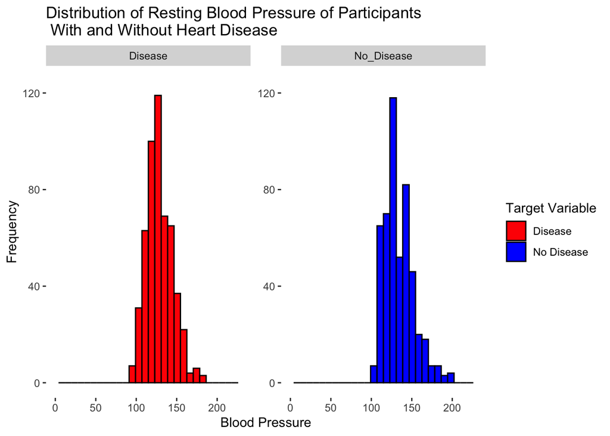

```r
ggplot(mydata.clean, aes(x=resting_blood_pressure, fill=factor(target))) +
geom_histogram(bindwith = 4, position = "dodge", color = "black")+
  xlim(0, 230)+
  ylim(0,125)+
labs(title="Distribution of Resting Blood Pressure of Participants \n With and Without Heart Disease", x="Blood Pressure", y="Frequency", fill="Target Variable") +
scale_fill_manual(values =c("No_Disease" = "blue", "Disease" = "red"), labels= c("Disease", "No Disease"))+
facet_wrap(~target, scales = "free_y", labeller = labeller(target =
    c("No Disease" = "No Disease",
      "Disease" = "Disease")))+
  theme(panel.background = element_blank())
```

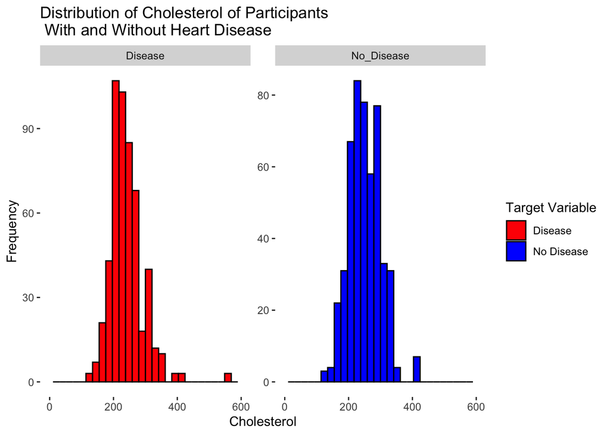

```r
ggplot(mydata.clean, aes(x=chol, fill=factor(target))) +
geom_histogram(bindwith = 4, position = "dodge", color = "black")+
  xlim(0,600)+
labs(title="Distribution of Cholesterol of Participants \n With and Without Heart Disease", x="Cholesterol", y="Frequency", fill="Target Variable") +
scale_fill_manual(values =c("No_Disease" = "blue", "Disease" = "red"), labels= c("Disease", "No Disease"))+
facet_wrap(~target, scales = "free_y", labeller = labeller(target =
    c("No Disease" = "No Disease",
      "Disease" = "Disease")))+
  theme(panel.background = element_blank())
```

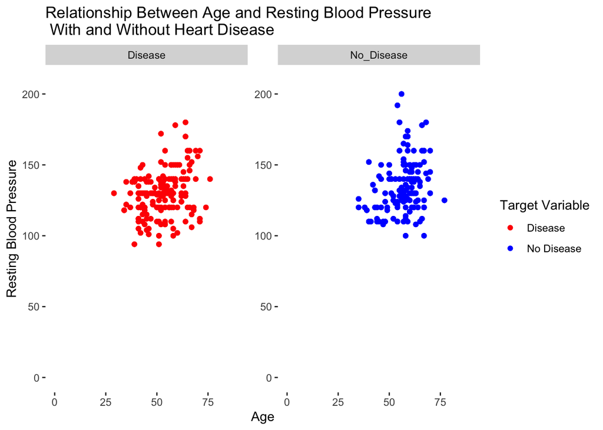

```r
ggplot(mydata.clean, aes(x=age, y=resting_blood_pressure, color=factor(target))) +
  geom_point()+
  xlim(0,90)+
  ylim(0,210)+
  #geom_bar()+
#geom_histogram(bindwith = 4, position = "dodge", color = "black")+
labs(title="Relationship Between Age and Resting Blood Pressure \n With and Without Heart Disease", x="Age", y="Resting Blood Pressure", color="Target Variable") +
  scale_color_manual(values =c("No_Disease" = "blue", "Disease" = "red"), labels= c("Disease", "No Disease"))+
#scale_fill_manual(values =c("0" = "blue", "1" = "red"), labels= c("No Disease", "Disease"))+
facet_wrap(~target, scales = "free_y", labeller = labeller(target =
    c("No Disease" = "No Disease",
      "Disease" = "Disease")))+
  #scale_fill_manual(values =c("0" = "blue", "1" = "red"), labels= c("No Disease", "Disease"))+
  theme(panel.background = element_blank())
```

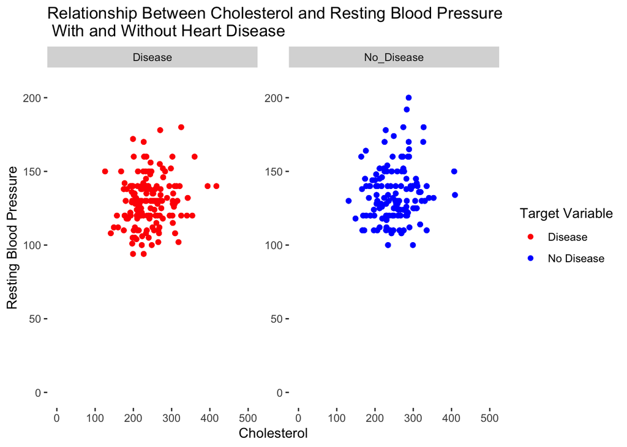

```r
ggplot(mydata.clean, aes(x=chol, y=resting_blood_pressure, color=factor(target))) +
  geom_point()+
  xlim(0,500)+
  ylim(0,210)+
  #expand_limits(x=0,y=0)+
  #geom_bar()+
#geom_histogram(bindwith = 4, position = "dodge", color = "black")+
labs(title="Relationship Between Cholesterol and Resting Blood Pressure \n With and Without Heart Disease", x="Cholesterol", y="Resting Blood Pressure", color="Target Variable") +
  scale_color_manual(values =c("No_Disease" = "blue", "Disease" = "red"), labels= c("Disease", "No Disease"))+
#scale_fill_manual(values =c("0" = "blue", "1" = "red"), labels= c("No Disease", "Disease"))+
facet_wrap(~target, scales = "free_y", labeller = labeller(target =
    c("No Disease" = "No Disease",
      "Disease" = "Disease")))+
  #scale_fill_manual(values =c("0" = "blue", "1" = "red"), labels= c("No Disease", "Disease"))+
  theme(panel.background = element_blank())
```

## Correlation Matrix

A correlation matrix plot is a visual representation of the pairwise correlation coefficients between variables in your dataset. The values in the matrix represent the correlation coefficient (often Pearson’s correlation) between two variables.

Interpret the Values:

High Positive Correlation (e.g., 0.8 or 0.9): Strong positive linear relationship between the two variables. For example, age and cholesterol levels might have a high positive correlation.

Moderate Correlation (e.g., 0.4 to 0.6): A moderate positive relationship. These variables are related, but not perfectly.

Low or No Correlation (e.g., 0.1 to 0.3 or close to 0): Weak or no linear relationship. These variables are not strongly associated.

Negative Correlation (e.g., -0.3 to -0.9): A negative relationship, where an increase in one variable corresponds to a decrease in the other.

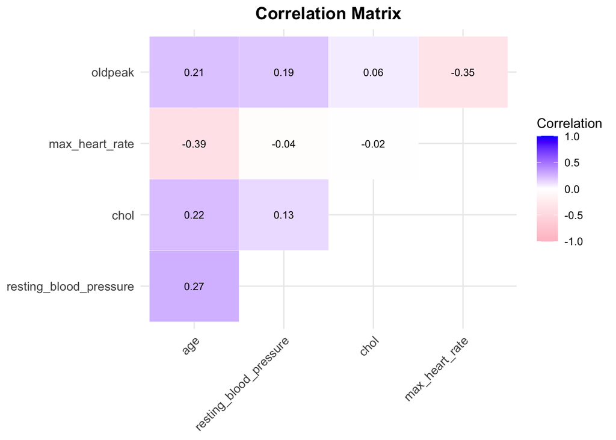

```r
cor_matrix <- cor(mydata.clean %>% select_if(where(is.numeric)), use = "complete.obs")

cor_long <- melt(cor_matrix)
cor_long <- cor_long[as.numeric(cor_long$Var1) > as.numeric(cor_long$Var2), ]


ggplot(cor_long, aes(Var2, Var1, fill = value)) +
  geom_tile(color = "white") +
  geom_text(aes(label = ifelse(value != 0, round(value, 2), "")),
            color = "black", size = 3, face="bold") +  # Show only significant values
  scale_fill_gradient2(low = "pink", high = "blue", mid = "white",
                       midpoint = 0, limit = c(-1, 1),
                       space = "Lab", name = "Correlation") +
  theme_minimal() +
  theme(
    axis.text.x = element_text(angle = 45, vjust = 1, hjust = 1, size = 10),  # Adjust x-axis label
    axis.text.y = element_text(size = 10),                                   # Adjust y-axis label
    axis.title = element_blank(),                                            # Remove axis titles
    plot.title = element_text(hjust = 0.5, face = "bold", size = 14)          # Center plot title
  ) +
  ggtitle("Correlation Matrix")
```

### Data Balance

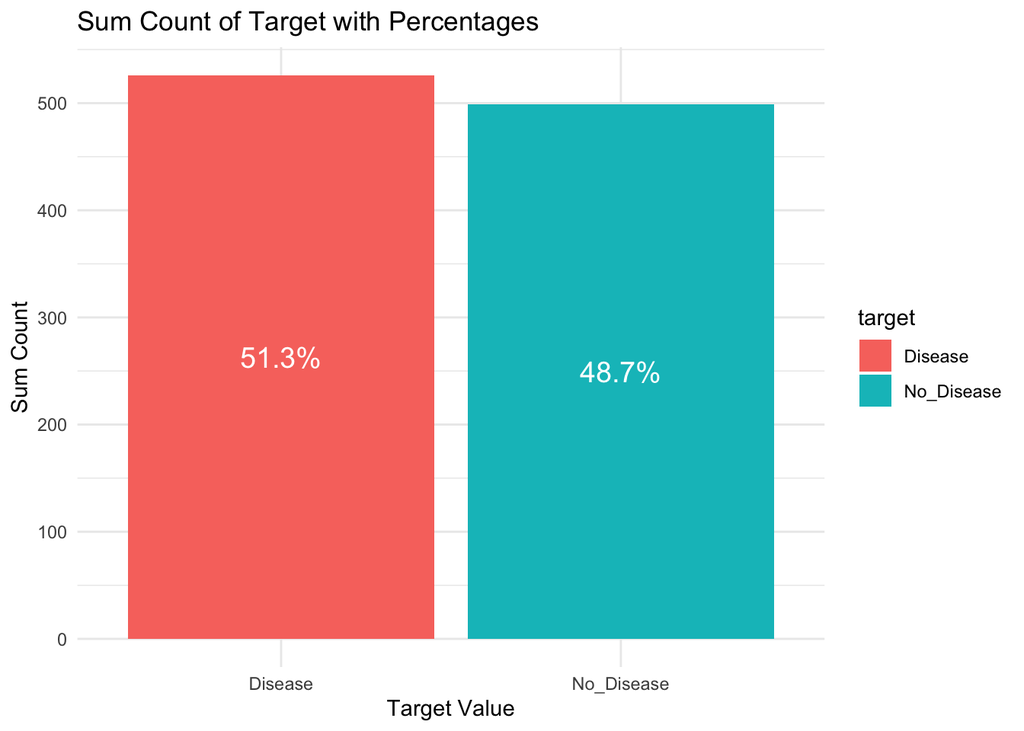

```r
summary_data <- mydata.clean %>%
  group_by(target) %>%
  summarise(sum_count = n()) %>%
  mutate(percentage = (sum_count / sum(sum_count)) * 100)


ggplot(summary_data, aes(x = target, y = sum_count, fill = target)) +
  geom_bar(stat = "identity") +
  geom_text(aes(label = paste0(round(percentage, 1), "%")),
            position = position_stack(vjust = 0.5), size = 5, color = "white") +
  labs(title = "Sum Count of Target with Percentages",
       x = "Target Value",
       y = "Sum Count") +
  theme_minimal()
```

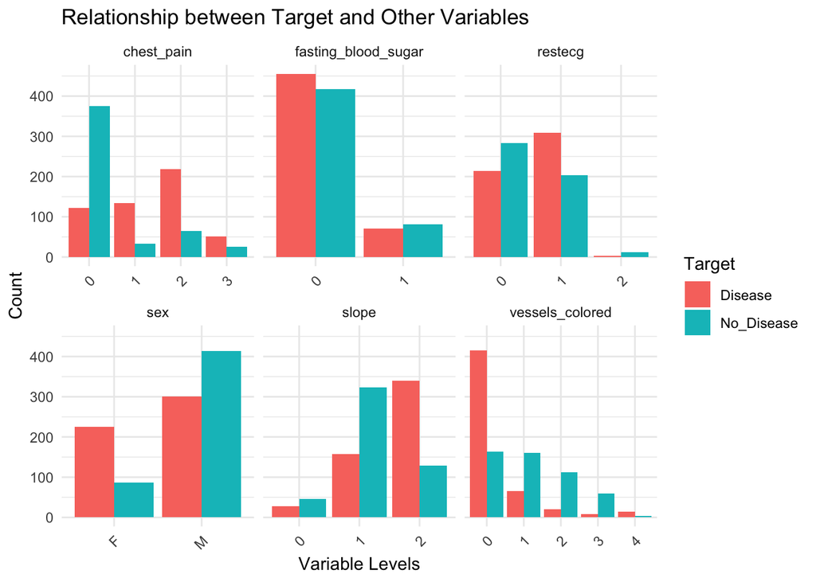

```r
#
variables <- c("sex", "chest_pain", "fasting_blood_sugar", "restecg", "slope", "vessels_colored")
plot_data <- lapply(variables, function(var) {
  mydata.clean |>
    group_by(across(all_of(var)), target) |>
    summarise(count = n(), .groups = "drop") |>
    mutate(variable = var, level = get(var))
}) %>%
  bind_rows()

# Create the faceted bar plot
ggplot(plot_data, aes(x = level, y = count, fill = factor(target))) +
  geom_bar(stat = "identity", position = "dodge") +
  facet_wrap(~variable, scales = "free_x") +
  labs(
    title = "Relationship between Target and Other Variables",
    x = "Variable Levels",
    y = "Count",
    fill = "Target"
  ) +
  theme_minimal() +
  theme(axis.text.x = element_text(angle = 45, hjust = 1))
```

## Splitting the data

```r
# Partition data - train (80%) - test(20%)
set.seed(1234)
indexSet <-sample(2, nrow(mydata.clean), replace = T, prob = c(0.8, 0.2))
train <- mydata.clean[indexSet==1,]
test <- mydata.clean[indexSet==2,]
```

## Model 1 - Logistic Regression

```r
set.seed(1234)
logistic_full <- glm(target ~., data=train, family = "binomial")
summary(logistic_full)
```

```
##
## Call:
## glm(formula = target ~ ., family = "binomial", data = train)
##
## Coefficients:
##                             Estimate Std. Error z value Pr(>|z|)
## (Intercept)                 1.030775   2.531705   0.407 0.683900
## age                        -0.022358   0.015938  -1.403 0.160679
## sexM                        2.229964   0.366784   6.080 1.20e-09 ***
## chest_pain1                -1.002458   0.352412  -2.845 0.004447 **
## chest_pain2                -1.829853   0.324661  -5.636 1.74e-08 ***
## chest_pain3                -2.397136   0.433164  -5.534 3.13e-08 ***
## resting_blood_pressure      0.019607   0.007107   2.759 0.005801 **
## chol                        0.006777   0.002479   2.734 0.006249 **
## fasting_blood_sugar1       -0.110189   0.354586  -0.311 0.755988
## restecg1                   -0.367211   0.248019  -1.481 0.138719
## restecg2                    1.142949   1.552465   0.736 0.461599
## max_heart_rate             -0.025627   0.007491  -3.421 0.000624 ***
## exercise_induced_anginayes  0.482475   0.285710   1.689 0.091279 .
## oldpeak                     0.323907   0.141685   2.286 0.022248 *
## slope1                      0.593526   0.504590   1.176 0.239494
## slope2                     -0.744162   0.536414  -1.387 0.165353
## vessels_colored1            2.075697   0.319671   6.493 8.40e-11 ***
## vessels_colored2            3.567304   0.500372   7.129 1.01e-12 ***
## vessels_colored3            2.076837   0.575896   3.606 0.000311 ***
## vessels_colored4           -1.788621   1.107311  -1.615 0.106249
## thal1                      -3.211949   1.970122  -1.630 0.103032
## thal2                      -2.697425   1.929289  -1.398 0.162070
## thal3                      -1.250892   1.931905  -0.647 0.517314
## ---
## Signif. codes:  0 '***' 0.001 '**' 0.01 '*' 0.05 '.' 0.1 ' ' 1
##
## (Dispersion parameter for binomial family taken to be 1)
##
##     Null deviance: 1123.84  on 810  degrees of freedom
## Residual deviance:  473.45  on 788  degrees of freedom
## AIC: 519.45
##
## Number of Fisher Scoring iterations: 6
```

## VIF Check

VIF quantifies how much the variance of a regression coefficient is inflated due to multicollinearity with other predictors in the model. A high VIF indicates that a predictor is highly correlated with other predictors, meaning it might be redundant.

Multicollinearity in logistic regression can cause inflated standard errors for the coefficients, making them unreliable. This can lead to problems with statistical significance testing and interpretation. High multicollinearity means that the model cannot determine the individual effect of correlated predictors, and you may end up with misleading results.

Interpretation of VIF Values: VIF = 1: No correlation with other predictors (ideal). 1 < VIF < 5: Moderate correlation; not a problem in most cases. VIF > 5 or 10: High correlation with other predictors; indicates potential multicollinearity issues. It suggests that you should consider removing or combining predictors.

```r
set.seed(1234)
vif(logistic_full)
```

```
##                             GVIF Df GVIF^(1/(2*Df))
## age                     1.505194  1        1.226863
## sex                     1.672999  1        1.293445
## chest_pain              1.944615  3        1.117221
## resting_blood_pressure  1.250533  1        1.118272
## chol                    1.330823  1        1.153613
## fasting_blood_sugar     1.158931  1        1.076537
## restecg                 1.182297  2        1.042754
## max_heart_rate          1.578211  1        1.256269
## exercise_induced_angina 1.197461  1        1.094286
## oldpeak                 1.540111  1        1.241012
## slope                   1.848202  2        1.165970
## vessels_colored         1.987327  4        1.089642
## thal                    1.516112  3        1.071820
```

## Feature Selection - Improve the model with StepAIC

AIC (Akaike Information Criterion) or BIC (Bayesian Information Criterion) are generally better choices than Pseudo’s R-squared.

AIC vs. BIC AIC (Akaike Information Criterion):

Focuses on finding the model that best balances goodness-of-fit and complexity. It penalizes the inclusion of extra predictors, but less strictly than BIC. Use AIC if prediction accuracy is the primary goal, as it tends to favor slightly more complex models.

BIC (Bayesian Information Criterion):

Similar to AIC but applies a stronger penalty for model complexity, especially with larger sample sizes. Use BIC if the focus is on selecting a parsimonious model (simpler with fewer predictors) or if your dataset is large.

```r
set.seed(1234)
logistic_2 <- stepAIC(logistic_full)
```

```
## Start:  AIC=519.45
## target ~ age + sex + chest_pain + resting_blood_pressure + chol +
##     fasting_blood_sugar + restecg + max_heart_rate + exercise_induced_angina +
##     oldpeak + slope + vessels_colored + thal
##
##                           Df Deviance    AIC
## - fasting_blood_sugar      1   473.54 517.54
## - restecg                  2   476.42 518.42
## - age                      1   475.42 519.42
## <none>                         473.45 519.45
## - exercise_induced_angina  1   476.27 520.27
## - oldpeak                  1   478.89 522.89
## - chol                     1   480.76 524.76
## - resting_blood_pressure   1   481.28 525.28
## - max_heart_rate           1   486.15 530.15
## - slope                    2   493.29 535.29
## - thal                     3   513.38 553.38
## - sex                      1   516.50 560.50
## - chest_pain               3   524.00 564.00
## - vessels_colored          4   573.95 611.95
##
## Step:  AIC=517.54
## target ~ age + sex + chest_pain + resting_blood_pressure + chol +
##     restecg + max_heart_rate + exercise_induced_angina + oldpeak +
##     slope + vessels_colored + thal
##
##                           Df Deviance    AIC
## - restecg                  2   476.50 516.50
## - age                      1   475.52 517.52
## <none>                         473.54 517.54
## - exercise_induced_angina  1   476.30 518.30
## - oldpeak                  1   479.07 521.07
## - chol                     1   480.81 522.81
## - resting_blood_pressure   1   481.28 523.28
## - max_heart_rate           1   486.44 528.44
## - slope                    2   493.29 533.29
## - thal                     3   513.81 551.81
## - sex                      1   516.53 558.53
## - chest_pain               3   525.86 563.86
## - vessels_colored          4   575.29 611.29
```

[output cut: 22 more lines]

```
##     exercise_induced_angina + oldpeak + slope + vessels_colored +
##     thal
##
##                           Df Deviance    AIC
## <none>                         478.19 516.19
## - exercise_induced_angina  1   481.07 517.07
## - oldpeak                  1   485.59 521.59
## - resting_blood_pressure   1   486.40 522.40
## - chol                     1   486.49 522.49
## - max_heart_rate           1   489.86 525.86
## - slope                    2   497.46 531.46
## - thal                     3   518.26 550.26
## - sex                      1   524.75 560.75
## - chest_pain               3   533.03 565.03
## - vessels_colored          4   583.50 613.50
```

```r
summary(logistic_2)
```

```
##
## Call:
## glm(formula = target ~ sex + chest_pain + resting_blood_pressure +
##     chol + max_heart_rate + exercise_induced_angina + oldpeak +
##     slope + vessels_colored + thal, family = "binomial", data = train)
##
## Coefficients:
##                             Estimate Std. Error z value Pr(>|z|)
## (Intercept)                -0.589701   2.584320  -0.228 0.819503
## sexM                        2.272252   0.362075   6.276 3.48e-10 ***
## chest_pain1                -1.079085   0.350476  -3.079 0.002078 **
## chest_pain2                -1.902186   0.320080  -5.943 2.80e-09 ***
## chest_pain3                -2.415082   0.427878  -5.644 1.66e-08 ***
## resting_blood_pressure      0.018292   0.006492   2.817 0.004841 **
## chol                        0.006854   0.002343   2.925 0.003444 **
## max_heart_rate             -0.023278   0.007123  -3.268 0.001083 **
## exercise_induced_anginayes  0.482331   0.282864   1.705 0.088163 .
## oldpeak                     0.364380   0.137064   2.658 0.007850 **
## slope1                      0.594352   0.498581   1.192 0.233226
## slope2                     -0.703620   0.526045  -1.338 0.181038
## vessels_colored1            2.020466   0.308625   6.547 5.88e-11 ***
## vessels_colored2            3.354136   0.475155   7.059 1.68e-12 ***
## vessels_colored3            1.989257   0.584376   3.404 0.000664 ***
## vessels_colored4           -1.724972   1.036780  -1.664 0.096157 .
## thal1                      -3.302675   2.236260  -1.477 0.139709
## thal2                      -2.690447   2.197068  -1.225 0.220740
## thal3                      -1.278720   2.198868  -0.582 0.560879
## ---
## Signif. codes:  0 '***' 0.001 '**' 0.01 '*' 0.05 '.' 0.1 ' ' 1
##
## (Dispersion parameter for binomial family taken to be 1)
##
##     Null deviance: 1123.84  on 810  degrees of freedom
## Residual deviance:  478.19  on 792  degrees of freedom
## AIC: 516.19
##
## Number of Fisher Scoring iterations: 6
```

# Logistic Regression Coefficient (logit Model)

- The coefficient differ by a scale factor and therefore we cannot interpret the magnitude of the coefficients
- coefficient interpretation:

```r
# Odds Ratios
set.seed(1234)
exp(logistic_2$coefficients)
```

```
##                (Intercept)                       sexM
##                 0.55449278                 9.70122397
##                chest_pain1                chest_pain2
##                 0.33990645                 0.14924205
##                chest_pain3     resting_blood_pressure
##                 0.08936005                 1.01846020
##                       chol             max_heart_rate
##                 1.00687714                 0.97699044
## exercise_induced_anginayes                    oldpeak
##                 1.61984611                 1.43962081
##                     slope1                     slope2
##                 1.81185730                 0.49479068
##           vessels_colored1           vessels_colored2
##                 7.54184194                28.62086038
##           vessels_colored3           vessels_colored4
##                 7.31009979                 0.17817800
##                      thal1                      thal2
##                 0.03678464                 0.06785061
##                      thal3
##                 0.27839329
```

# Marginal Effect

The marginal effect refers to the change in the probability of the outcome (i.e., the dependent variable) associated with a one-unit change in a predictor variable, holding all other variables constant. Since logistic regression models the log-odds of the outcome, the marginal effect is a way to interpret the effect of a predictor variable in terms of actual probabilities, which is more intuitive.

Marginal effects interpretation:

```r
# Logit model average marginal effects
set.seed(1234)
LogitScalar <- mean(dlogis(predict(logistic_2, type="link")))
avg_m_effects <- LogitScalar*coef(logistic_2)
avg_m_effects
```

```
##                (Intercept)                       sexM
##              -0.0538679592               0.2075653217
##                chest_pain1                chest_pain2
##              -0.0985720709              -0.1737605650
##                chest_pain3     resting_blood_pressure
##              -0.2206124916               0.0016709235
##                       chol             max_heart_rate
##               0.0006260614              -0.0021264326
## exercise_induced_anginayes                    oldpeak
##               0.0440599095               0.0332853043
##                     slope1                     slope2
##               0.0542928138              -0.0642742110
##           vessels_colored1           vessels_colored2
##               0.1845652488               0.3063930696
##           vessels_colored3           vessels_colored4
##               0.1817143268              -0.1575724922
##                      thal1                      thal2
##              -0.3016922167              -0.2457665238
##                      thal3
##              -0.1168083548
```

# McFadden’s Pseudo R-squared

Pseudo R-squared is a measure of model fit in logistic regression, similar to R-squared in linear regression, but it doesn’t represent the proportion of variance explained. Instead, it quantifies how well the model explains the data compared to a null model (a model with no predictors).

McFadden’s R-squared: Based on the log-likelihood ratio between the fitted model and the null model. Values closer to 1 indicate better fit.

Soure: “https://kapooramanpreet.github.io/documents/research/papers/Wolf,Kapoor,Hobson&Gardner-McCune_SIGCSE2023_Internships_Paper.pdf” McFadden, D. 1977. Quantitative Methods for Analyzing Travel Behaviour of Individuals: Some Recent Developments.

```r
set.seed(1234)
pseudo_r2 <- pR2(logistic_2)
```

```
## fitting null model for pseudo-r2
```

```r
pseudo_r2
```

```
##          llh      llhNull           G2     McFadden         r2ML         r2CU
## -239.0947171 -561.9197783  645.6501224    0.5745038    0.5489225    0.7320306
```

# Predicting test data set and Accuracy.

1. We use K-fold cross validation

“In K-fold cross-validation, the data set is divided into a number of K-folds and used to assess the model’s ability as new data become available. K represents the number of groups into which the data sample is divided. For example, if you find the k value to be 5, you can call it 5-fold cross-validation.”

```r
# Assess model using Cross Validation
set.seed(1234)
crossValSettings <- trainControl(method = "repeatedcv", number = 10, savePredictions = TRUE)

crossVal <- train(target ~ age + sex + chest_pain + resting_blood_pressure + chol + max_heart_rate +
    exercise_induced_angina + oldpeak + slope + vessels_colored + thal, data=train, family = "binomial", method = "glm", trControl = crossValSettings)

crossVal
```

```
## Generalized Linear Model
##
## 811 samples
##  11 predictor
##   2 classes: 'Disease', 'No_Disease'
##
## No pre-processing
## Resampling: Cross-Validated (10 fold, repeated 1 times)
## Summary of sample sizes: 729, 730, 730, 730, 730, 730, ...
## Resampling results:
##
##   Accuracy   Kappa
##   0.8557964  0.7108937
```

```r
pred <- predict(crossVal, newdata = test)
confusionMatrix(data = pred, test$target)
```

```
## Confusion Matrix and Statistics
##
##             Reference
## Prediction   Disease No_Disease
##   Disease        101         21
##   No_Disease      10         82
##
##                Accuracy : 0.8551
##                  95% CI : (0.8007, 0.8994)
##     No Information Rate : 0.5187
##     P-Value [Acc > NIR] : < 2e-16
##
##                   Kappa : 0.7088
##
##  Mcnemar's Test P-Value : 0.07249
##
##             Sensitivity : 0.9099
##             Specificity : 0.7961
##          Pos Pred Value : 0.8279
##          Neg Pred Value : 0.8913
##              Prevalence : 0.5187
##          Detection Rate : 0.4720
##    Detection Prevalence : 0.5701
##       Balanced Accuracy : 0.8530
##
##        'Positive' Class : Disease
##
```

## Model 2 - Random Forest

1. A very low OOB (Out-of-bag) value suggest overfitting:
2. Reducing the complexity of the random forest model by decreasing the number of trees, limiting the maximum depth of trees, or removing features.

```r
set.seed(1234)
rf <- randomForest(target ~ ., data=train, proximity=TRUE, importance =TRUE, do.trace = 10, ntree = 50)
```

```
## ntree      OOB      1      2
##    10:   2.37%  1.46%  3.33%
##    20:   1.11%  1.20%  1.01%
##    30:   0.86%  1.20%  0.51%
##    40:   0.74%  0.72%  0.76%
##    50:   0.37%  0.24%  0.51%
```

```r
rf
```

```
##
## Call:
##  randomForest(formula = target ~ ., data = train, proximity = TRUE,      importance = TRUE, do.trace = 10, ntree = 50)
##                Type of random forest: classification
##                      Number of trees: 50
## No. of variables tried at each split: 3
##
##         OOB estimate of  error rate: 0.37%
## Confusion matrix:
##            Disease No_Disease class.error
## Disease        414          1 0.002409639
## No_Disease       2        394 0.005050505
```

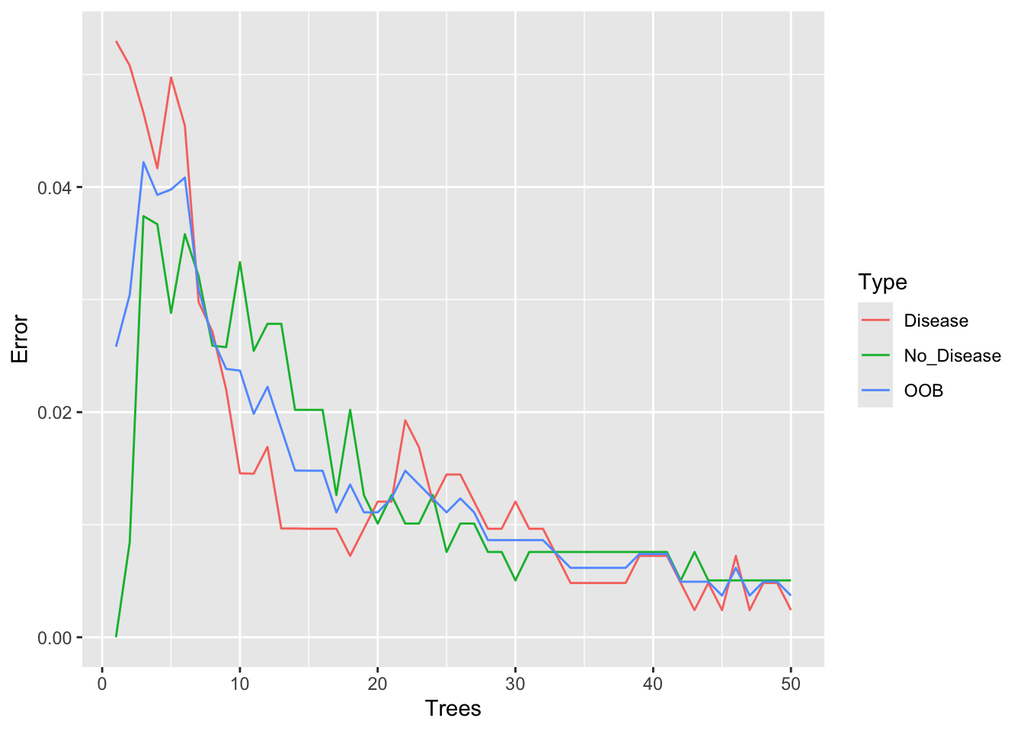

```r
# Plot the error rate to see what is the suitable number of trees.
set.seed(1234)
oob.error.data <- data.frame(
  Trees=rep(1:nrow(rf$err.rate), times=3),
  Type=rep(c("OOB", "Disease", "No_Disease"), each=nrow(rf$err.rate)),
  Error=c(rf$err.rate[,"OOB"],
    rf$err.rate[,"Disease"],
    rf$err.rate[,"No_Disease"]))

ggplot(data=oob.error.data, aes(x=Trees, y=Error)) +
  geom_line(aes(color=Type))
```

```r
set.seed(1234)
rf2 <- randomForest(target ~ ., data=train, proximity=TRUE, importance =TRUE, ntree = 5)
rf2
```

```
##
## Call:
##  randomForest(formula = target ~ ., data = train, proximity = TRUE,      importance = TRUE, ntree = 5)
##                Type of random forest: classification
##                      Number of trees: 5
## No. of variables tried at each split: 3
##
##         OOB estimate of  error rate: 3.98%
## Confusion matrix:
##            Disease No_Disease class.error
## Disease        363         19  0.04973822
## No_Disease      10        337  0.02881844
```

# Feature Selection:

The function varImpPlot() in Random Forest regression (and classification) is used to visualize the importance of each predictor (independent variable) in the model. It helps to understand which features contribute most to the model’s predictions. This is particularly useful when you have many predictor variables and want to identify which ones are most influential.

Purpose of varImpPlot() in Random Forest Regression: Feature Importance: varImpPlot() plots the importance of each variable in the model, allowing you to assess which variables have the greatest effect on the target variable.

Model Interpretation: By visualizing feature importance, you can identify key predictors and gain insights into your data and model. This helps in understanding the model’s behavior and making decisions about which features to retain, remove, or transform.

Dimensionality Reduction: If certain variables have very low importance, you might decide to drop them from the model to reduce complexity, improve interpretability, and potentially improve model performance.

Here we removed fbs, restecg, slope variables as they are less important.

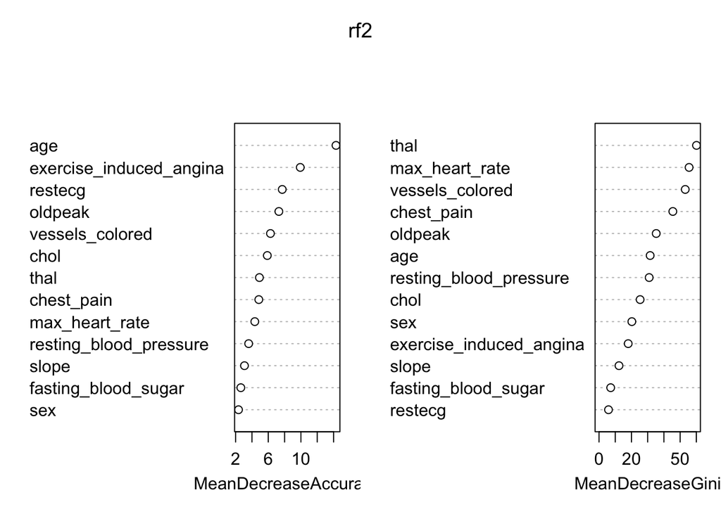

```r
#Variable Importance - which variables can we remove?
set.seed(1234)
varImpPlot(rf2)
```

# Final model and accessing classification accuracy

```r
set.seed(1234)
rf3 <- randomForest(target ~ age + sex + chest_pain + resting_blood_pressure + chol + max_heart_rate +
    exercise_induced_angina + oldpeak + vessels_colored + thal, data=train, proximity=TRUE, importance =TRUE, ntree = 5)
rf3
```

```
##
## Call:
##  randomForest(formula = target ~ age + sex + chest_pain + resting_blood_pressure +      chol + max_heart_rate + exercise_induced_angina + oldpeak +      vessels_colored + thal, data = train, proximity = TRUE, importance = TRUE,      ntree = 5)
##                Type of random forest: classification
##                      Number of trees: 5
## No. of variables tried at each split: 3
##
##         OOB estimate of  error rate: 3.53%
## Confusion matrix:
##            Disease No_Disease class.error
## Disease        366         13  0.03430079
## No_Disease      13        344  0.03641457
```

```r
set.seed(1234)
result <- data.frame(test$target, predict(rf3, test[, 0:13], type="response"))
head(result)
```

```
##    test.target predict.rf3..test...0.13...type....response..
## 5   No_Disease                                    No_Disease
## 14  No_Disease                                    No_Disease
## 16     Disease                                       Disease
## 26  No_Disease                                    No_Disease
## 28  No_Disease                                    No_Disease
## 29  No_Disease                                    No_Disease
```

```r
set.seed(1234)
confusionMatrix(result$predict.rf3..test...0.13...type....response.., result$test.target)
```

```
## Confusion Matrix and Statistics
##
##             Reference
## Prediction   Disease No_Disease
##   Disease        111          6
##   No_Disease       0         97
##
##                Accuracy : 0.972
##                  95% CI : (0.94, 0.9896)
##     No Information Rate : 0.5187
##     P-Value [Acc > NIR] : < 2e-16
##
##                   Kappa : 0.9437
##
##  Mcnemar's Test P-Value : 0.04123
##
##             Sensitivity : 1.0000
##             Specificity : 0.9417
##          Pos Pred Value : 0.9487
##          Neg Pred Value : 1.0000
##              Prevalence : 0.5187
##          Detection Rate : 0.5187
##    Detection Prevalence : 0.5467
##       Balanced Accuracy : 0.9709
##
##        'Positive' Class : Disease
##
```

## Which model can better classify? -ROC Curve and AUC

To determine which model performs better we use AUC-ROC Curve:

AUC-ROC evaluates the ability of a model to distinguish between classes across various thresholds. A higher AUC indicates better discrimination ability.The model with the higher AUC is generally better.

Random Forest Model has higher AUC and below ROC Curve suggest Random Forest Model is better.

```r
set.seed(1234)
par(pty="s")
roc(train$target, logistic_2$fitted.values, plot=TRUE, legacy.axes=TRUE, percent=TRUE,
    xlab="False Positive Percentage", ylab="True Positive Percentage", col="#0ABAB5",  print.auc=TRUE)
```

```
##
## Call:
## roc.default(response = train$target, predictor = logistic_2$fitted.values,     percent = TRUE, plot = TRUE, legacy.axes = TRUE, xlab = "False Positive Percentage",     ylab = "True Positive Percentage", col = "#0ABAB5", print.auc = TRUE)
##
## Data: logistic_2$fitted.values in 415 controls (train$target Disease) < 396 cases (train$target No_Disease).
## Area under the curve: 94.62%
```

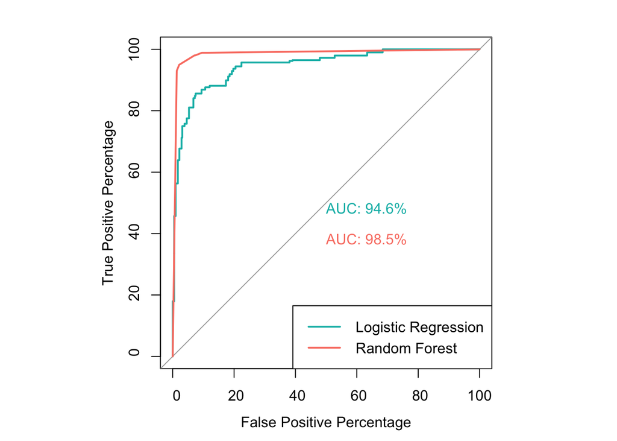

```r
plot.roc(train$target, rf3$votes[,1], percent=TRUE, col="#FA8072", print.auc=TRUE, add=TRUE, print.auc.y=40)
legend("bottomright", legend=c("Logistic Regression", "Random Forest"), col=c("#0ABAB5","#FA8072"), lwd=2)
```